# Semaine 01 - Comprendre une base avant de modéliser

MQT-2101 - Analyse et modélisation des données

## Objectifs de la séance

Cette première séance installe un réflexe simple : avant de modéliser, il faut savoir ce qu’une base décrit, comment les variables sont codées et ce que les résumés permettent réellement de conclure.

1

nommer l’unité d’observation

2

classer les variables

3

décrire et comparer prudemment

## Fonctionnement du cours

Le cours est organisé par semaines. Chaque semaine combine des capsules, des exercices, des démonstrations R, des ateliers ou des traces courtes.

- Deux mini-rapports en équipe de 2 à 3 comptent pour 15 % chacun.
- L’examen intra et l’examen final sont individuels, en personne, et comptent pour 30 % et 40 %.
- Les questionnaires servent de pratique formative non évaluée.
- L’IA est non permise aux examens, permise avec déclaration dans les mini-rapports, et permise dans le travail personnel.

Le [GPT du cours](https://chatgpt.com/g/g-6a0b2ec33d948191ad25b2f247b15de1-analyse-et-modelisation-des-donnees?ref=mini) doit être utilisé pour les activités liées au cours. Son rôle est celui d’un tuteur : aider à comprendre, questionner, vérifier et déboguer, sans remplacer votre jugement.

## Le fil conducteur

Départ ouvrir la base

Lire une ligne = quoi?

Préparer rendre les variables interprétables

Décrire résumer une variable

Comparer changer l’échelle avec prudence

Trace garder une preuve courte

La trace finale ne doit pas tout recopier. Elle doit montrer que vous avez compris le passage de la base brute à un constat descriptif défendable.

## Pourquoi commencer par la base?

Un modèle peut être techniquement correct et répondre à la mauvaise question.

Avant le calcul Que représente une ligne? Quelle variable mesure quoi? Quelle comparaison est raisonnable?

Après le calcul Le résultat décrit-il la base, une association, une prévision ou une cause?

## Partie 1 : lire la base

Point de départ

## Une ligne de birth_us.csv

Dans cette base, une ligne correspond à une journée d’observation.

year 2000

month 1

date_of_month 1

day_of_week 6

births 9083

La même ligne contient des morceaux de date, un code de jour et un nombre de naissances. Ces colonnes ne se résument pas toutes de la même façon.

## Observation et variable

Observation L’unité décrite par une ligne. Ici : une journée.

Variable Une caractéristique décrite par une colonne. Ici : année, mois, jour, code de semaine, naissances.

Unité de mesure Ce que les valeurs mesurent. Ici, `births` est un nombre quotidien de naissances.

Rôle possible Une variable peut servir à décrire, à grouper, à comparer ou à situer dans le temps.

## Lire quelques lignes

| year | month | date_of_month | day_of_week | births |
| --- | --- | --- | --- | --- |
| 1994 | 1 | 1 | 6 | 8096 |
| 1994 | 1 | 2 | 7 | 7772 |
| 1994 | 1 | 3 | 1 | 10142 |
| 1994 | 1 | 4 | 2 | 11248 |
| 1994 | 1 | 5 | 3 | 11053 |

L’objectif n’est pas encore de calculer. L’objectif est de comprendre la structure de la base.

## Types de variables

Numérique Une quantité ou une mesure. Exemple : `births`.

Catégorielle Des groupes ou modalités. Exemple : jour de la semaine.

Date Un repère temporel complet. Exemple : 2000-01-01.

Code Un nombre qui identifie une catégorie. Exemple : `day_of_week`.

## Quand un nombre n’est pas une quantité

`day_of_week` contient des nombres de 1 à 7. Pourtant, la moyenne de ces codes n’a pas de sens utile.

À éviter La moyenne de `day_of_week` est 4, donc le jour moyen est jeudi.

À faire Transformer le code en catégorie : lundi, mardi, mercredi, etc.

## Partie 2 : préparer sans trahir

Rendre la base interprétable

## Préparer, c’est rendre explicite

Avant `year`, `month`, `date_of_month`

Après une vraie variable `date`

Avant `day_of_week` = 1 à 7

Après `jour_semaine` = catégorie lisible

Avant variables brutes

Après base prête à résumer

## Deux transformations utiles

On ne modifie pas au hasard. On rend plus lisible ce qui est déjà dans la base.

| Dans la base brute | Transformation utile | Pourquoi? |
| --- | --- | --- |
| `year`, `month`, `date_of_month` | une variable `date` | situer chaque journée dans le temps |
| `day_of_week` codé 1 à 7 | une catégorie `jour_semaine` | comparer des jours plutôt que moyenner des codes |

## Vérifications rapides

| Lignes | Dates distinctes | Valeurs manquantes | Codes inattendus |
| --- | --- | --- | --- |
| 3652 | 3652 | 0 | 0 |

Ces vérifications ne prouvent pas que la base est parfaite. Elles évitent de résumer une variable mal lue ou mal codée.

## Partie 3 : décrire une variable

Analyse univariée

## La question devient plus précise

Que peut-on dire du nombre quotidien de naissances observé dans la base?

Variable étudiée `births`

Unité d’observation une journée

Résumés utiles minimum, moyenne, médiane, maximum

Graphique utile histogramme de la distribution

## Résumé numérique

| jours | minimum | moyenne | mediane | maximum |
| --- | --- | --- | --- | --- |
| 3652 | 6443 | 10876.8 | 11615 | 14540 |

La moyenne donne un niveau moyen. La médiane donne une valeur centrale moins sensible aux valeurs très petites ou très grandes.

## Histogramme de `births`

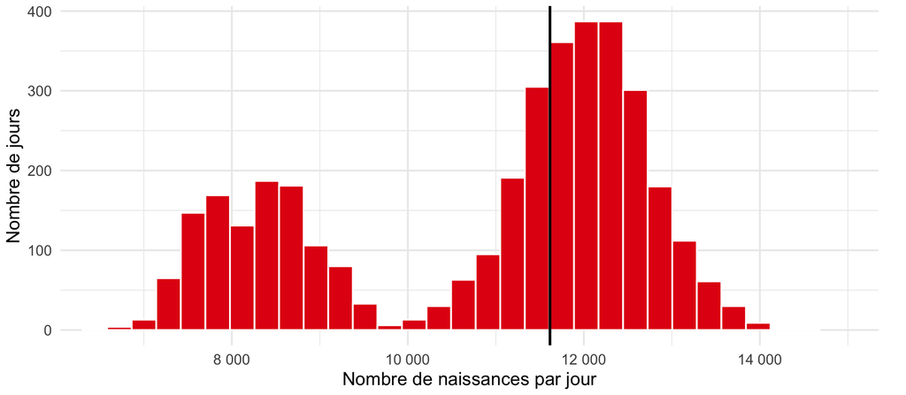

La ligne noire marque la médiane. Le graphique aide à voir la concentration des valeurs et les journées plus inhabituelles.

## Écrire un constat prudent

Acceptable Dans cette base, `births` décrit un nombre quotidien de naissances. Le tableau et l’histogramme résument les valeurs observées sans expliquer leurs causes.

Trop fort Le graphique prouve pourquoi certains jours ont moins de naissances.

Au module 1, on apprend surtout à décrire et à limiter l’interprétation.

## Partie 4 : comparer prudemment

Analyse bivariée descriptive

## Comparer, c’est changer la question

Les naissances observées semblent-elles varier selon le jour de la semaine?

Variable numérique `births`

Variable de groupe `jour_semaine`

Graphique boxplots côte à côte

Limite un écart visible n’est pas une explication causale

## `births` selon le jour

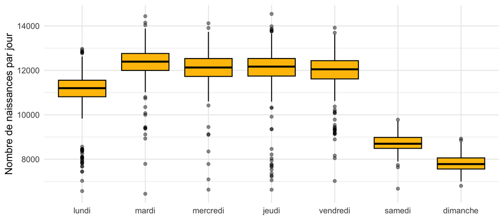

Le boxplot compare les distributions. Il attire l’attention sur les centres, les dispersions et les valeurs plus extrêmes.

## Nombre brut ou taux?

Dans safety_airlines.csv, un nombre brut d’incidents ne tient pas compte de la taille des compagnies ni de leur volume d’activité.

| airline | incidents_00_14 | incidents_par_milliard |
| --- | --- | --- |
| Pakistan International | 10 | 0.037 |
| Saudi Arabian | 11 | 0.016 |
| Sri Lankan / AirLanka | 4 | 0.016 |
| Ethiopian Airlines | 5 | 0.013 |
| Gulf Air | 3 | 0.013 |

## Même base, deux lectures

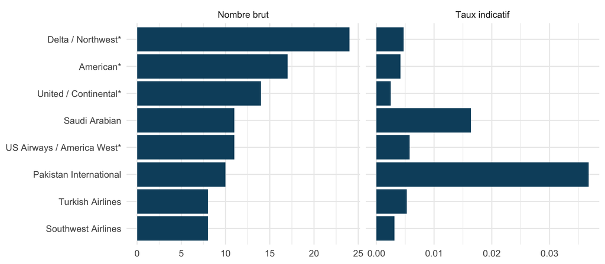

Changer d’échelle peut changer l’histoire racontée par les données. C’est exactement pour cela qu’il faut nommer l’indicateur utilisé.

## Partie 5 : produire une trace

Portfolio

## Ce que la trace doit montrer

1. Base Je sais dire ce que représente une ligne.

2. Variables Je sais classer quelques variables et nommer une précaution.

3. Résumé Je sais produire un tableau descriptif et un graphique.

4. Interprétation Je sais écrire deux constats descriptifs et une limite.

## Exemple de limite utile

Phrase utilisable Ces résultats décrivent les valeurs observées dans la base. Ils ne permettent pas, à eux seuls, d’expliquer les causes des différences observées ni de généraliser à un autre contexte.

Une limite n’affaiblit pas l’analyse. Elle montre que l’interprétation est maîtrisée.

## Trois réflexes à garder

1

nommer l’unité avant de calculer

2

adapter le résumé au type de variable

3

écrire ce que le résultat ne permet pas de conclure

## Activité de consolidation

À partir de vos exercices, préparez une trace finale d’une page maximum. La trace doit pouvoir être comprise sans explication orale.

- une phrase sur le rôle d’un modèle;
- un classement de quelques variables;
- un tableau descriptif et un graphique;
- deux constats descriptifs;
- une limite d’interprétation.

## Auto-vérification assistée par IA

Utilisez le [GPT du cours](https://chatgpt.com/g/g-6a0b2ec33d948191ad25b2f247b15de1-analyse-et-modelisation-des-donnees?ref=mini) comme tuteur pour relire votre trace finale, pas pour la rédiger à votre place.

Demande possible : « Voici ma trace finale pour la semaine 01. Vérifie si elle contient tous les éléments attendus. Indique les éléments manquants, les passages imprécis et les questions que je devrais me poser. Ne réécris pas ma trace à ma place. »

Après cette vérification, notez une correction apportée à votre trace ou une question qui reste à clarifier.

## À conserver

MQT-2101

Avant de passer au module suivant, gardez une version stable de votre trace et notez une notion à consolider dans vos propres mots.